# problem set 2

2024-03-06

```r
library('tidyverse')
library(rsample)
library(caret)  # For RMSE calculation
library(forcats)
```

```r
movies <- read_csv("datasets/IMDB_movies.csv")
```

```r
movies_clean <-
  movies %>%
  mutate(budgetM = budget/1000000,
         grossM = gross/1000000,
         profitM = grossM - budgetM,
         ROI = profitM/budgetM,
         genre_main = as.factor(unlist(map(strsplit(as.character(movies$genres),"\\|"),1))) %>% fct_lump(12),
         rating_simple = fct_lump(content_rating, n = 6)
  ) %>%
  filter(budget < 400000000,
         content_rating != "",
         content_rating != "Not Rated",
         language == "English") %>%
  mutate(rating_simple = rating_simple %>% fct_drop()) %>%
  rename(director = director_name,
         title = movie_title,
         year = title_year) %>%
  select(-c(actor_1_name, actor_2_name,actor_1_facebook_likes, actor_2_facebook_likes,
            budget, gross, aspect_ratio, num_voted_users,num_user_for_reviews)) %>%
  relocate(title, year, country, director, budgetM, grossM, profitM, ROI, imdb_score, genre_main, rating_simple, language, duration)
```

# part b.

```r
set.seed(310)
movies_split <- initial_split(movies_clean, prop = 0.8)
movies_train <- training(movies_split)
movies_test <- testing(movies_split)
```

# part c.

```r
movies_train$rating_simple <- relevel(movies_train$rating_simple, ref = "R")

model <- lm(grossM ~ imdb_score + budgetM + rating_simple, data = movies_train)
summary(model)
```

```
##
## Call:
## lm(formula = grossM ~ imdb_score + budgetM + rating_simple, data = movies_train)
##
## Residuals:
##     Min      1Q  Median      3Q     Max
## -370.68  -26.00   -8.28   16.17  484.03
##
## Coefficients:
##                       Estimate Std. Error t value Pr(>|t|)
## (Intercept)          -94.69468    6.21756 -15.230  < 2e-16 ***
## imdb_score            15.61448    0.92700  16.844  < 2e-16 ***
## budgetM                0.97327    0.02316  42.029  < 2e-16 ***
## rating_simpleG        33.74727    6.34817   5.316 1.14e-07 ***
## rating_simpleMissing -11.70681   10.41910  -1.124    0.261
## rating_simplePG       23.26882    2.88223   8.073 9.89e-16 ***
## rating_simplePG-13    17.14975    2.27851   7.527 6.88e-14 ***
## rating_simpleOther     3.86416    8.39777   0.460    0.645
## ---
## Signif. codes:  0 '***' 0.001 '**' 0.01 '*' 0.05 '.' 0.1 ' ' 1
##
## Residual standard error: 51.56 on 2930 degrees of freedom
## Multiple R-squared:  0.4878, Adjusted R-squared:  0.4866
## F-statistic: 398.6 on 7 and 2930 DF,  p-value: < 2.2e-16
```

# part d. A higher budget indicates a higher gross profit as the coefficient is positive, a budget increase of one unit will increase gross return by .97 million $.It is significant as P is < 0.05

# part e. In respect to the reference level rating of R, A movie of G rating will have the largest impact on the gross return, with on average a return of 33.74 million dollars more grossing than R rated movies respectively. And pg13 which grosses 17.14 million more than R on movies on average. The G rating is also significant as the p value < 0.05.

# part f. p value is 2e-16, so an incredibly small number, way smaller than 0.05. This means that the null hypothesis being imbd score does not affect gross return can be rejected. It is almost with 100% certainty that the higher the imdb score, the more grossing a film will make.

# part g.

```r
train_predictions <- predict(model, movies_train)
test_predictions <- predict(model, movies_test)
```

# Combine actual and predicted values in the test set for plotting

```r
test_results <- movies_test %>%
  mutate(predicted_grossM = test_predictions)
```

# part h.

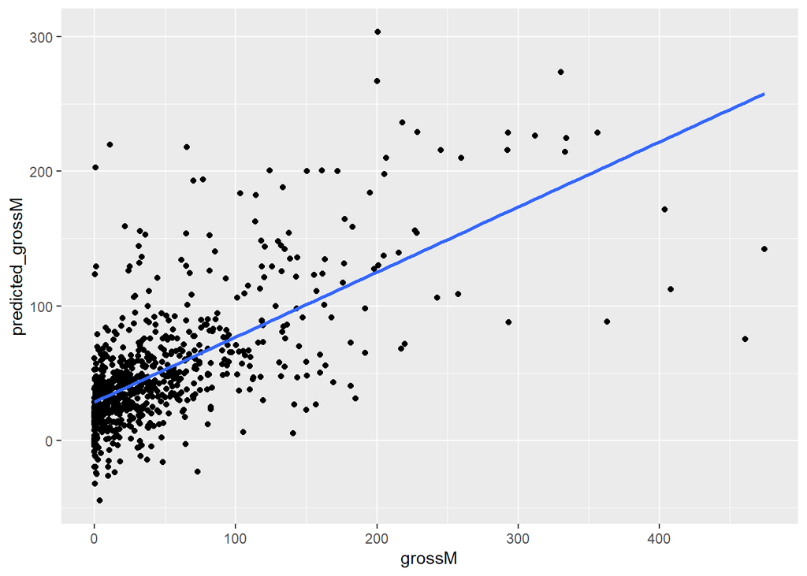

# part i.

```r
rmse_train <- RMSE(train_predictions, movies_train$grossM)
rmse_test <- RMSE(test_predictions, movies_test$grossM)

rmse_train
```

```
## [1] 51.48504
```

```r
rmse_test
```

```
## [1] 50.24709
```

# The model is not overfit or underfit, as the test set does not have a higher or significantly higher rmse than the training set, our model is decent at generalizing because the training / testing sets have similar rmse’s.

# The model does have a pretty big error though, on average its wrong by around 50 million dollars in predicting gross score, but that can be improved by adding more independent variables.